# NYC Shooting Incidents

Nicholas Anadon

2025-04-12

-Data set is NYPD Shooting Incident Data(Historic) last updated on 4/26/2024 on catalog.data.gov.

-Data entries range from 1/1/2006 to 12/29/2023

-What boroughs have more incidents than others and how many total incidents are there across all boroughs?

```r
#This code starts the cleaning process
nyshooting <- "https://data.cityofnewyork.us/api/views/833y-fsy8/rows.csv?accessType=DOWNLOAD"
nyshooting <- read.csv(nyshooting)

#Changing weird values to UNKNOWN so most data is not lost
sore_val <- c("", "(null)", "1028", "1020", "940", "224", "1022")

#Changing names of columns to easier names
nyshooting <- rename(nyshooting, ID_Key = "INCIDENT_KEY", Date = "OCCUR_DATE", Time = "OCCUR_TIME", Boro = "BORO", Inci_Loc = "LOCATION_DESC", Death = "STATISTICAL_MURDER_FLAG",
                     Perp_Age = "PERP_AGE_GROUP", Perp_Sex = "PERP_SEX", Perp_Race = "PERP_RACE",
                     Vic_Age = "VIC_AGE_GROUP", Vic_Sex = "VIC_SEX", Vic_Race = "VIC_RACE", Precinct =
                       "PRECINCT", Jur_Code = "JURISDICTION_CODE") %>%
 select(-"LOC_OF_OCCUR_DESC", -"LOC_CLASSFCTN_DESC", -"X_COORD_CD", -"Y_COORD_CD",
        -"Latitude", -"Longitude", -"Lon_Lat", -"ID_Key", -"Inci_Loc") %>%
  mutate(across(where(is.character),
                ~ifelse(.x %in% sore_val, "UNKNOWN", .x)))

nyshooting <- na.omit(nyshooting)
nyshooting$Date <- as.Date(nyshooting$Date, format = "%m/%d/%Y")
nyshooting$Death <- as.logical(nyshooting$Death)
nyshooting$Jur_Code <- as.factor(nyshooting$Jur_Code)
nyshooting$Boro <- as.factor(nyshooting$Boro)
nyshooting$Precinct <- as.factor(nyshooting$Precinct)
nyshooting$Perp_Age <- as.factor(nyshooting$Perp_Age)
nyshooting$Perp_Sex <- as.factor(nyshooting$Perp_Sex)
nyshooting$Perp_Race <- as.factor(nyshooting$Perp_Race)
nyshooting$Vic_Age <- as.factor(nyshooting$Vic_Age)
nyshooting$Vic_Sex <- as.factor(nyshooting$Vic_Sex)
nyshooting$Vic_Race <- as.factor(nyshooting$Vic_Race)
#Variable Changes
#Date: character -> date
#Death: character -> logical
#All other variables: character -> factor

#Only 2 entries out of 28,562 entries contained NA values. Values are omitted
#Date allows for quantitative analysis over a selected time
#Logical for death illustrates a binary choice between survival and death of victim
#Factor variables allow for easier categorical variable analysis

head(nyshooting)
```

```
##         Date     Time     Boro Precinct Jur_Code Death Perp_Age Perp_Sex
## 1 2021-08-09 01:06:00    BRONX       40        0 FALSE  UNKNOWN  UNKNOWN
## 2 2018-04-07 19:48:00 BROOKLYN       79        0  TRUE    25-44        M
## 3 2022-12-02 22:57:00    BRONX       47        0 FALSE  UNKNOWN  UNKNOWN
## 4 2006-11-19 01:50:00 BROOKLYN       66        0  TRUE  UNKNOWN        U
## 5 2010-05-09 01:58:00    BRONX       46        0  TRUE    25-44        M
## 6 2012-07-22 21:35:00    BRONX       42        2 FALSE    18-24        M
##        Perp_Race Vic_Age Vic_Sex Vic_Race
## 1        UNKNOWN   18-24       M    BLACK
## 2 WHITE HISPANIC   25-44       M    BLACK
## 3        UNKNOWN   25-44       M    BLACK
## 4        UNKNOWN   18-24       M    BLACK
## 5          BLACK     <18       F    BLACK
## 6          BLACK   18-24       M    BLACK
```

```r
#Transformed data set nydeath of how many incidents occurred on each day
nydeath <- nyshooting %>%
  arrange(Date)

nydeath <- nydeath %>%
  group_by(Date, Death) %>%
  summarise(count = n(), .groups = "drop")

head(nydeath)
```

```
## # A tibble: 6 × 3
##   Date       Death count
##   <date>     <lgl> <int>
## 1 2006-01-01 FALSE     4
## 2 2006-01-01 TRUE      4
## 3 2006-01-02 FALSE     3
## 4 2006-01-02 TRUE      1
## 5 2006-01-03 FALSE     3
## 6 2006-01-03 TRUE      1
```

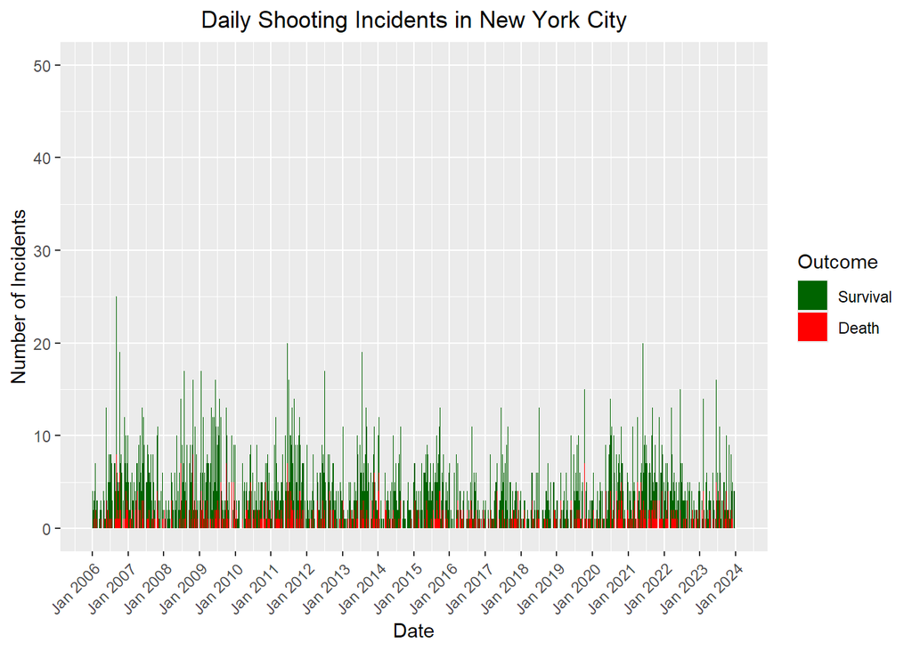

```r
#Condensed bar chart where survival incidents stack on death incidents
#Total incidents for a given day are illustrated by the top point of survival bars
nydeath %>%
  ggplot(aes(x = Date, y = count, fill = Death)) +
  geom_col(position = "stack") +
  labs(title = "Daily Shooting Incidents in New York City",
       x = "Date", y = "Number of Incidents") +
  scale_x_date(date_labels = "%b %Y", date_breaks = "1 year") +
  scale_y_continuous(limits = c(0, 50)) +
  scale_fill_manual(values = c("TRUE" = "red", "FALSE" = "darkgreen"),
                    name = "Outcome",
                    labels = c("FALSE" = "Survival", "TRUE" = "Death")) +
  theme(axis.text.x = element_text(angle = 45, hjust = 1)) +
  theme(plot.title = element_text(hjust = 0.5))
```

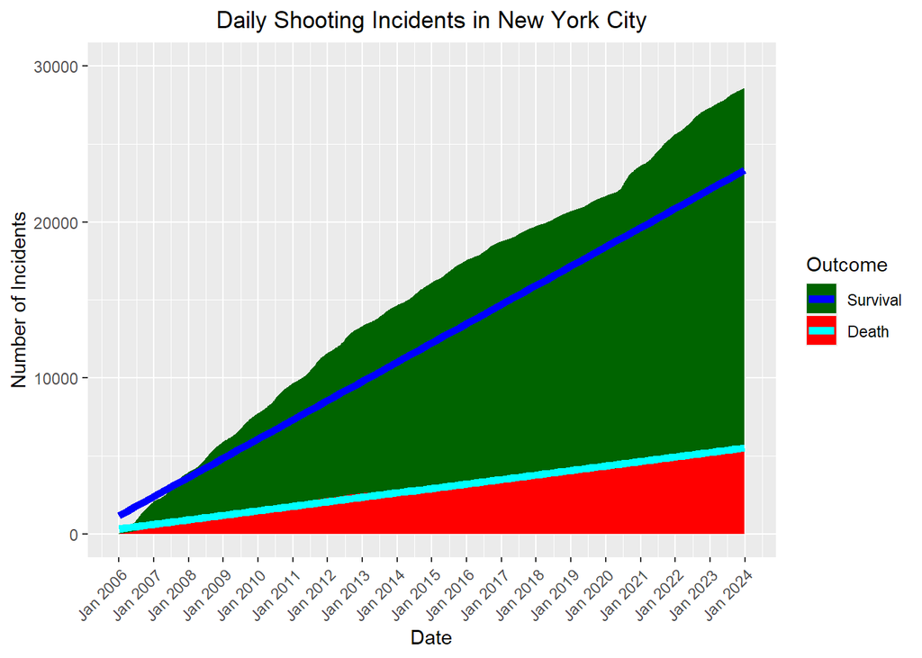

```r
#Transformed cumulative data set nydeath_cuml that shows the total amount of incidents over time
nydeath_cuml <- nydeath %>%
  arrange(Date) %>%
  group_by(Death) %>%
  mutate(cumulative_count = cumsum(count))

#Condensed area chart of total amount of incidents over time
#Same stacked bar rule as the stacked bar chart
#Blue line: Linear line of best fit for survival incidents
#Cyan line: Linear line of best fit for death incidents
nydeath_cuml %>%
  ggplot(aes(x = Date, y = cumulative_count, fill = Death, color = Death)) +
  geom_area(position = "stack", color = NA) +
  geom_smooth(method = "lm", se = FALSE, linewidth = 2) +
  labs(title = "Daily Shooting Incidents in New York City",
       x = "Date", y = "Number of Incidents",
       fill = "Outcome", color = "Outcome") +
  scale_x_date(date_labels = "%b %Y", date_breaks = "1 year") +
  scale_y_continuous(limits = c(0, 30000)) +
  scale_color_manual(values = c("TRUE" = "cyan", "FALSE" = "blue"),
                     name = "Outcome",
                     labels = c("TRUE" = "Death", "FALSE" = "Survival")
                     ) +
  scale_fill_manual(values = c("TRUE" = "red", "FALSE" = "darkgreen"),
                    name = "Outcome",
                    labels = c("TRUE" = "Death", "FALSE" = "Survival")) +
  theme(axis.text.x = element_text(angle = 45, hjust = 1)) +
  theme(plot.title = element_text(hjust = 0.5))
```

```r
#Transformed data set nyboro that shows the amount of incidents within each NYC borough
nyboro <- nyshooting %>%
  arrange(Boro)

nyboro <- nyboro %>%
  group_by(Boro, Death) %>%
  summarise(count = n(), .groups = "drop")

nyboro
```

```
## # A tibble: 10 × 3
##    Boro          Death count
##    <fct>         <lgl> <int>
##  1 BRONX         FALSE  6742
##  2 BRONX         TRUE   1634
##  3 BROOKLYN      FALSE  9136
##  4 BROOKLYN      TRUE   2210
##  5 MANHATTAN     FALSE  3089
##  6 MANHATTAN     TRUE    672
##  7 QUEENS        FALSE  3430
##  8 QUEENS        TRUE    840
##  9 STATEN ISLAND FALSE   637
## 10 STATEN ISLAND TRUE    170
```

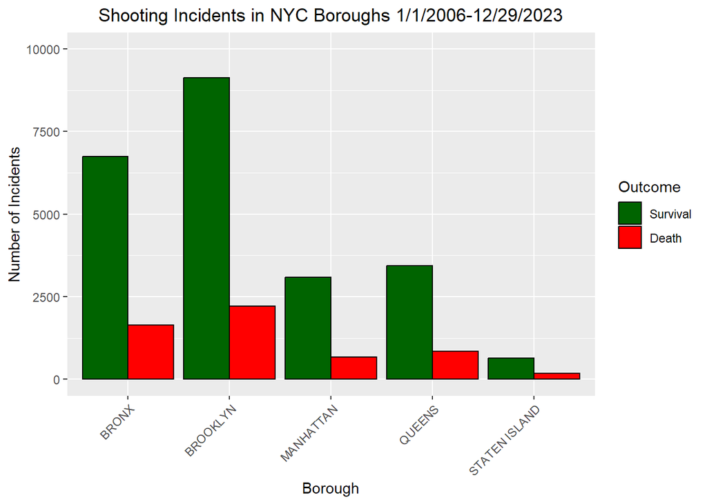

```r
#Bar chart showing incidents in boroughs across the data's timeframe
nyboro %>%
  ggplot(aes(x = Boro, y = count, fill = Death)) +
  geom_col(position = "dodge", color = 'black') +
  scale_y_continuous(limits = c(0, 10000)) +
  scale_fill_manual(values = c("TRUE" = "red", "FALSE" = "darkgreen"),
                               name = "Outcome",
                               labels = c("FALSE" = "Survival", "TRUE" = "Death")) +
  theme(axis.text.x = element_text(angle = 45, hjust = 1)) +
  theme(plot.title = element_text(hjust = 0.5)) +
  labs(title = "Shooting Incidents in NYC Boroughs 1/1/2006-12/29/2023",
       x = "Borough",
       y = "Number of Incidents",
       fill = "Death")
```

```r
#Linear model of deaths as time passes
mod <- lm(count ~ Date, data = nydeath)
mod
```

```
##
## Call:
## lm(formula = count ~ Date, data = nydeath)
##
## Coefficients:
## (Intercept)         Date
##   5.0093509   -0.0001105
```

```r
summary(mod)
```

```
##
## Call:
## lm(formula = count ~ Date, data = nydeath)
##
## Residuals:
##    Min     1Q Median     3Q    Max
## -2.557 -1.978 -0.918  0.989 33.029
##
## Coefficients:
##               Estimate Std. Error t value Pr(>|t|)
## (Intercept)  5.0093509  0.2372181  21.117  < 2e-16 ***
## Date        -0.0001105  0.0000144  -7.672 1.88e-14 ***
## ---
## Signif. codes:  0 '***' 0.001 '**' 0.01 '*' 0.05 '.' 0.1 ' ' 1
##
## Residual standard error: 2.637 on 8917 degrees of freedom
## Multiple R-squared:  0.006557,   Adjusted R-squared:  0.006445
## F-statistic: 58.85 on 1 and 8917 DF,  p-value: 1.877e-14
```

**Data Bias:** There are differing law enforcement standards within each NYC borough, so the results may not show the true danger within each area. Death is a logical argument in the cleaned data set, so we do not know the extent of how much victims were injured before they died or survived. Race and age of attackers and victims were not variables of interest for what I wanted to uncover. Bias statements to consider when looking over the cleaned data and analysis.

```r
write.csv(nyshooting, "nyshooting_cleaned.csv")
```